# Kỹ thuật lập trình Python

## Làm quen với Numpy

### Bài 1. Tính toán trên dãy số

#### 1. Tạo một dãy số a có N phần tử (N = 10)

```python
import numpy as np # Khai báo thư viện numpy

print("1. Tạo một dãy số a có N phần tử (N = 10)")
""" CÁC BẠN LÀM BÀI Ở ĐÂY """
a = np.arange(10)  # Tạo dãy số từ 0 đến 9

print("Day so a: ", a)
```

```
1. Tạo một dãy số a có N phần tử (N = 10)
Day so a:  [0 1 2 3 4 5 6 7 8 9]
```

#### 2. Các thao tác trên dãy số a

(a) Bình phương các phần tử trong dãy số  
(b) Tìm số lượng các phần tử của dãy số  
(c) In ra giá trị lớn nhất, giá trị nhỏ nhất và giá trị trung bình  
(d) Tính phương sai của dãy số $\sigma^2 = \frac{\sum{\left(a_i - \mu\right)^2}}{N - 1}$ với $\mu = \frac{\sum{a_i}}{N}$ và độ lệch chuẩn $var = \sqrt{\sigma^2}$

```python
import numpy as np
import math

# Dãy số đầu vào
a = [120, 183, 160, 175, 145, 162, 190, 160, 152, 162]

# a. Bình phương các phần tử trong dãy số
a_squared = [x**2 for x in a]
print("a. Binh phuong a: ", a_squared)

# b. Tìm số lượng các phần tử của dãy số
length = len(a)
print("b. Do dai a: ", length)

# c. In ra giá trị lớn nhất, giá trị nhỏ nhất và giá trị trung bình
max_val = max(a)
min_val = min(a)
mean_val = sum(a) / len(a)
print("c. Gia tri lon nhat: [{}], gia tri nho nhat: [{}], gia tri trung binh [{:.1f}]".format(max_val, min_val, mean_val))

# d. Tính phương sai và độ lệch chuẩn
# Tính giá trị trung bình μ
mu = sum(a) / len(a)

# Tính tổng bình phương độ lệch
sum_squared_deviation = sum((x - mu)**2 for x in a)

# Tính phương sai (σ²)
variance = sum_squared_deviation / (len(a) - 1)

# Tính độ lệch chuẩn (var = √σ²)
std_deviation = math.sqrt(variance)

print("d. Phuong sai: [{: .2f}] va do lech chuan: [{: .2f}]".format(variance, std_deviation))
```

```
a. Binh phuong a:  [14400, 33489, 25600, 30625, 21025, 26244, 36100, 25600, 23104, 26244]
b. Do dai a:  10
c. Gia tri lon nhat: [190], gia tri nho nhat: [120], gia tri trung binh [160.9]
d. Phuong sai: [ 393.66] va do lech chuan: [ 19.84]
```

#### 3. Toán tử trên hai dãy số

(a) Tạo dãy số x có 10 phần tử từ 1 đến 10 (dùng hàm np.arange)  
(b) Liệt kê và đếm số lượng phần tử chẵn và lẻ có trong dãy a và x  
(c) Tính khoảng cách giữa các phần tử ở vị trí lẻ của mảng a và x với $s = \sqrt{\sum{\left(a_i - x_i\right)^2}}$ với $i$ lẻ  
(d) Tìm khoảng cách nhỏ nhất giữa tập a và x. Ví dụ: min({1, 3, 5}, {2, 10, 8}} = 1

```python
import numpy as np
import math

print("3. Xử lý khác trên dãy số")

# Dãy số a đã cho
a = [120, 183, 160, 175, 145, 162, 190, 160, 152, 162]

# a. Tạo dãy số x có 10 phần tử từ 1 đến 10 (dùng hàm np.arange)
x = np.arange(1, 11)
print(f'a. Day so x: {x}')
```

```
3. Xử lý khác trên dãy số
a. Day so x: [ 1  2  3  4  5  6  7  8  9 10]
```

```python
import numpy as np
import math

print("3. Xử lý khác trên dãy số")

# Dãy số a đã cho
a = np.array([120, 183, 160, 175, 145, 162, 190, 160, 152, 162])

# b. Liệt kê và đếm số lượng phần tử chẵn và lẻ có trong dãy a và x
a_la_chan = a % 2 == 0
a_chan = a[a_la_chan]
n_a_chan = len(a_chan)

x_la_chan = x % 2 == 0
x_chan = x[x_la_chan]
n_x_chan = len(x_chan)

print("b. Cac phan tu chan trong day a, b: ")
print(f"+ Day a: {a}")
print(f"  - Loc chan: {a_la_chan}")
print(f"  - Day chua phan tu chan trong a: {a_chan}, so luong {n_a_chan} phan tu.")
print(f"+ Day x: {x}")
print(f"  - Loc chan: {x_la_chan}")
print(f"  - Day chua phan tu chan trong x: {x_chan}, so luong {n_x_chan} phan tu.")
```

```
3. Xử lý khác trên dãy số
b. Cac phan tu chan trong day a, b:
+ Day a: [120 183 160 175 145 162 190 160 152 162]
  - Loc chan: [ True False  True False False  True  True  True  True  True]
  - Day chua phan tu chan trong a: [120 160 162 190 160 152 162], so luong 7 phan tu.
+ Day x: [ 1  2  3  4  5  6  7  8  9 10]
  - Loc chan: [False  True False  True False  True False  True False  True]
  - Day chua phan tu chan trong x: [ 2  4  6  8 10], so luong 5 phan tu.
```

```python
import numpy as np
import math

print("3. Xử lý khác trên dãy số")

# Dãy số a đã cho
a = np.array([120, 183, 160, 175, 145, 162, 190, 160, 152, 162])


# c. Tính hiệu các phần tử ở vị trí lẻ của mảng a và x
v_le = [i for i in range(len(a)) if i % 2 != 0]  # Vị trí lẻ (index 1, 3, 5, 7, 9)
a_le = a[v_le]
x_le = x[v_le]
hieu_le = a_le - x_le
kc_le = math.sqrt(sum(hieu_le**2))

print("c. Tính hiệu các phần tử ở vị trí lẻ của mảng a và x: ")
print(f"+ Vi tri le trong a va x: {v_le}")
print(f"+ Day so a: {a} va cac so o vi tri le: {a_le}")
print(f"+ Day so x: {x} va cac so o vi tri le: {x_le}")
print(f"+ Hieu cua a va x o vi tri le: {hieu_le}")
print(f"+ Khoang cach cac phan tu cua a va x o vi tri le: {kc_le: .2f}")
```

```
3. Xử lý khác trên dãy số
c. Tính hiệu các phần tử ở vị trí lẻ của mảng a và x:
+ Vi tri le trong a va x: [1, 3, 5, 7, 9]
+ Day so a: [120 183 160 175 145 162 190 160 152 162] va cac so o vi tri le: [183 175 162 160 162]
+ Day so x: [ 1  2  3  4  5  6  7  8  9 10] va cac so o vi tri le: [ 2  4  6  8 10]
+ Hieu cua a va x o vi tri le: [181 171 156 152 152]
+ Khoang cach cac phan tu cua a va x o vi tri le:  364.07
```

```python
import numpy as np
import math

print("3. Xử lý khác trên dãy số")

# Dãy số a đã cho
a = np.array([120, 183, 160, 175, 145, 162, 190, 160, 152, 162])

# d. Tìm khoảng cách nhỏ nhất giữa tập a và x
print("d. Tìm khoảng cách nhỏ nhất giữa tập a và x. Ví dụ: min({1, 3, 5}, {2, 10, 8}) = 1")

# Sử dụng broadcasting để tính khoảng cách giữa tất cả các phần tử
a_reshaped = a[:, np.newaxis]  # Chuyển a thành ma trận cột (10, 1)
x_reshaped = x[np.newaxis, :]  # Chuyển x thành ma trận hàng (1, 10)

# Tính khoảng cách giữa tất cả các cặp phần tử
distances = np.abs(a_reshaped - x_reshaped)

# Tìm khoảng cách nhỏ nhất
v_min = np.min(distances)

print(f"+ Day a: {a}")
print(f"+ Day x: {x}")
print(f"+ Khoang cach nho nhat: {v_min}")
```

```
3. Xử lý khác trên dãy số
d. Tìm khoảng cách nhỏ nhất giữa tập a và x. Ví dụ: min({1, 3, 5}, {2, 10, 8}) = 1
+ Day a: [120 183 160 175 145 162 190 160 152 162]
+ Day x: [ 1  2  3  4  5  6  7  8  9 10]
+ Khoang cach nho nhat: 110
```

#### 4. Sinh ngẫu nhiên dãy số

(a) Sinh ngẫu nhiên dãy số có 100 phần tử theo phân bố đều với giá trị trong đoạn [1, 10] và vẽ đồ thị tần số xuất hiện
(b) Sinh ngẫu nhiên N diem (x, y) với y là hàm phân phối chuẩn $N(\mu = 1, \sigma^2 = 1.0)$:
$$ y = f\left(x| \mu, \sigma\right) = \frac{1}{\sigma\sqrt{2\pi}}exp\left(-\frac{\left(x - \mu\right)^2}{2\sigma^2}\right) $$ nơi mà $x \in [\mu - 5\sigma, \mu + 5\sigma]$
(c) Sinh ngẫu nhiên dãy số có 100000 phần tử theo phân bố chuẩn $N(\mu = 1, \sigma^2 = 1.0)$ và vẽ đồ thị tần số xuất hiện

```
4. Sinh ngẫu nhiên dãy số
a. Sinh ngẫu nhiên theo phân bố đều
+ Gia tri: [ 1  2  3  4  5  6  7  8  9 10]
+ So lan xuat hien: [ 7  8 12  8 14  9 17  8  6 11]
+ Do thi ham so xuat hien
```

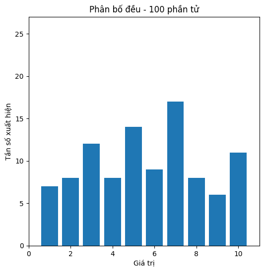

[figure not shown]

[figure not shown]

[output not shown]

```python
import numpy as np
import matplotlib.pyplot as plt
from scipy.stats import norm

print("4. Sinh ngẫu nhiên dãy số")

# a. Sinh ngẫu nhiên dãy số có 100 phần tử theo phân bố đều [1, 10]
uniform_data = np.random.randint(1, 11, 100)  # Sinh số nguyên từ 1 đến 10
value, cnt = np.unique(uniform_data, return_counts=True)

print("a. Sinh ngẫu nhiên theo phân bố đều")
print(f"+ Gia tri: {value}")
print(f"+ So lan xuat hien: {cnt}")
print("+ Do thi ham so xuat hien")
plt.figure(figsize=(6,6))
plt.bar(value, cnt)
plt.xlim(0, 11)
plt.ylim(0, np.max(cnt) + 10)
plt.xlabel('Giá trị')
plt.ylabel('Tần số xuất hiện')
plt.title('Phân bố đều - 100 phần tử')
plt.savefig("4a.png")
plt.show()
```

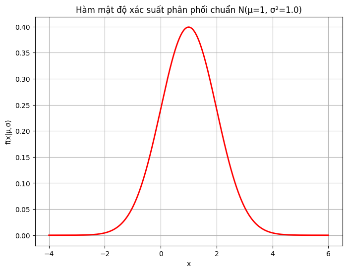

```
b. Sinh ngẫu nhiên N điểm (x, y) với phân phối chuẩn
+ Số điểm N: 1000
+ Khoảng x: từ -4.00 đến 6.00
+ Giá trị y lớn nhất: 0.3989 tại x = 1
```

```python
# b. Sinh ngẫu nhiên N điểm (x, y) với phân phối chuẩn
mu, sigma = 1, 1.0
N = 1000  # Số điểm

# Tạo các điểm x trong khoảng [μ-5σ, μ+5σ]
x_range = np.linspace(mu - 5*sigma, mu + 5*sigma, N)

# Tính giá trị y theo hàm mật độ xác suất chuẩn
y_pdf = (1/(sigma * np.sqrt(2*np.pi))) * np.exp(-0.5 * ((x_range - mu)/sigma)**2)

# Vẽ đồ thị
plt.figure(figsize=(8,6))
plt.plot(x_range, y_pdf, 'r-', lw=2)
plt.xlabel('x')
plt.ylabel('f(x|μ,σ)')
plt.title('Hàm mật độ xác suất phân phối chuẩn N(μ=1, σ²=1.0)')
plt.grid(True)
plt.savefig("4b.png")
plt.show()

# In thông tin
print("b. Sinh ngẫu nhiên N điểm (x, y) với phân phối chuẩn")
print(f"+ Số điểm N: {N}")
print(f"+ Khoảng x: từ {mu-5*sigma:.2f} đến {mu+5*sigma:.2f}")
print(f"+ Giá trị y lớn nhất: {np.max(y_pdf):.4f} tại x = {mu}")
```

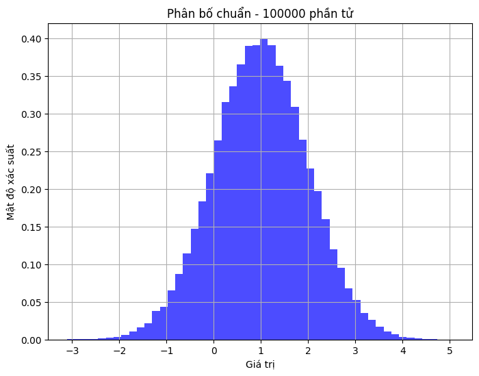

```
c. Sinh ngẫu nhiên theo phân bố chuẩn
+ Trung bình: 0.9986
+ Độ lệch chuẩn: 0.9962
+ Min: -3.1019
+ Max: 5.0686
```

```python
# c. Sinh ngẫu nhiên dãy số có 100000 phần tử theo phân bố chuẩn
normal_data = np.random.normal(mu, sigma, 100000)

# Vẽ histogram
plt.figure(figsize=(8,6))
plt.hist(normal_data, bins=50, density=True, alpha=0.7, color='blue')
plt.xlabel('Giá trị')
plt.ylabel('Mật độ xác suất')
plt.title('Phân bố chuẩn - 100000 phần tử')
plt.grid(True)
plt.savefig("4c.png")
plt.show()

# Tính và hiển thị thống kê cơ bản
print("c. Sinh ngẫu nhiên theo phân bố chuẩn")
print(f"+ Trung bình: {np.mean(normal_data):.4f}")
print(f"+ Độ lệch chuẩn: {np.std(normal_data):.4f}")
print(f"+ Min: {np.min(normal_data):.4f}")
print(f"+ Max: {np.max(normal_data):.4f}")
```

### Bài 2. Tính toán trên ma trận

#### 1. Tạo ma trận a có M = 6 dòng, N = 4 cột

```python
import numpy as np

print("Bài 2. Tính toán trên ma trận")

# 1. Tạo ma trận a có M = 6 dòng, N = 4 cột
M, N = 6, 4
a = np.arange(1, 25).reshape(6, 4)

print("1. Ma trận a có M = 6 dòng, N = 4 cột:")
print(a)
print(f"Kích thước ma trận: {a.shape}")
print(f"Số phần tử: {a.size}")
```

```
Bài 2. Tính toán trên ma trận
1. Ma trận a có M = 6 dòng, N = 4 cột:
[[ 1  2  3  4]
 [ 5  6  7  8]
 [ 9 10 11 12]
 [13 14 15 16]
 [17 18 19 20]
 [21 22 23 24]]
Kích thước ma trận: (6, 4)
Số phần tử: 24
```

#### 2. Các thao tác trên ma trận a

(a) In ra ma trận chuyển vị  
(b) In ra phần tử ở vị trí dòng 2 cột 3  
(c) Trích xuất dòng đầu, dòng cuối, dòng 2  
(d) Trích xuất cột kế cuối, cột đầu  
(e) Đảo các giá trị trên từng cột  
(f) Tính tổng các dòng, trung bình các cột

```python
import numpy as np

print("Bài 2. Tính toán trên ma trận")

# 1. Tạo ma trận a có M = 6 dòng, N = 4 cột
M, N = 6, 4
a = np.arange(1, 25).reshape(6, 4)

print("1. Ma trận a có M = 6 dòng, N = 4 cột:")
print(a)
print(f"Kích thước ma trận: {a.shape}")
print(f"Số phần tử: {a.size}")

print("\n2. Các thao tác trên ma trận a")

# (a) In ra ma trận chuyển vị
a_transpose = a.T
print("(a) Ma trận chuyển vị:")
print(a_transpose)

# (b) In ra phần tử ở vị trí dòng 2 cột 3
# Lưu ý: Index trong Python bắt đầu từ 0
element = a[2, 3]
print(f"(b) Phần tử ở dòng 2 cột 3: {element}")

# (c) Trích xuất dòng đầu, dòng cuối, dòng 2
first_row = a[0, :]
last_row = a[-1, :]
second_row = a[1, :]
print("(c) Trích xuất dòng:")
print(f"  - Dòng đầu: {first_row}")
print(f"  - Dòng cuối: {last_row}")
print(f"  - Dòng 2: {second_row}")

# (d) Trích xuất cột kế cuối, cột đầu
second_last_col = a[:, -2]
first_col = a[:, 0]
print("(d) Trích xuất cột:")
print(f"  - Cột kế cuối: {second_last_col}")
print(f"  - Cột đầu: {first_col}")

# (e) Đảo các giá trị trên từng cột
a_reversed = np.flipud(a)
print("(e) Đảo các giá trị trên từng cột:")
print(a_reversed)

# (f) Tính tổng các dòng, trung bình các cột
row_sums = np.sum(a, axis=1)
col_means = np.mean(a, axis=0)
print("(f) Tính toán:")
print(f"  - Tổng các dòng: {row_sums}")
print(f"  - Trung bình các cột: {col_means}")
```

```
Bài 2. Tính toán trên ma trận
1. Ma trận a có M = 6 dòng, N = 4 cột:
[[ 1  2  3  4]
 [ 5  6  7  8]
 [ 9 10 11 12]
 [13 14 15 16]
 [17 18 19 20]
 [21 22 23 24]]
Kích thước ma trận: (6, 4)
Số phần tử: 24

2. Các thao tác trên ma trận a
(a) Ma trận chuyển vị:
[[ 1  5  9 13 17 21]
 [ 2  6 10 14 18 22]
 [ 3  7 11 15 19 23]
 [ 4  8 12 16 20 24]]
(b) Phần tử ở dòng 2 cột 3: 12
(c) Trích xuất dòng:
  - Dòng đầu: [1 2 3 4]
  - Dòng cuối: [21 22 23 24]
  - Dòng 2: [5 6 7 8]
(d) Trích xuất cột:
  - Cột kế cuối: [ 3  7 11 15 19 23]
  - Cột đầu: [ 1  5  9 13 17 21]
(e) Đảo các giá trị trên từng cột:
[[21 22 23 24]
 [17 18 19 20]
 [13 14 15 16]
 [ 9 10 11 12]
 [ 5  6  7  8]
 [ 1  2  3  4]]
(f) Tính toán:
  - Tổng các dòng: [10 26 42 58 74 90]
  - Trung bình các cột: [11. 12. 13. 14.]
```

#### 3. Các toán tử trên hai ma trận

(a) Tạo hai ma trận A và B có 4 dòng x 3 cột và X có 3 dòng x 4 cột  
(b) Tính tổng, hiệu, tích của từng phần tử trên hai ma trận A và B  
(c) Tính phép nhân ma trận Y = A x X

```python
import numpy as np

print("3. Các toán tử trên hai ma trận")

# (a) Tạo hai ma trận A và B có 4 dòng x 3 cột và X có 3 dòng x 4 cột
A = np.array([[1, 2, 3],
              [4, 5, 6],
              [7, 8, 9],
              [10, 11, 12]])

B = np.array([[2, 3, 4],
              [5, 6, 7],
              [8, 9, 10],
              [11, 12, 13]])

X = np.array([[1, 2, 3, 4],
              [5, 6, 7, 8],
              [9, 10, 11, 12]])

print("a. Tạo hai ma trận A và B có 4 dòng x 3 cột và X có 3 dòng x 4 cột")
print(f"+ Ma tran A: \n{A}")
print(f"+ Ma tran B: \n{B}")
print(f"+ Ma tran X: \n{X}")

# (b) Tính tổng, hiệu, tích của từng phần tử trên hai ma trận A và B
AB_add = A + B
AB_sub = A - B
AB_mul = A * B  # Nhân từng phần tử (element-wise)

print("\nb. Tính tổng, hiệu, tích của từng phần tử trên hai ma trận A và B")
print(f"A + B = \n{AB_add}")
print(f"A - B = \n{AB_sub}")
print(f"A . B = \n{AB_mul}")

# (c) Tính phép nhân ma trận Y = A x X
Y = np.dot(A, X)  # Hoặc có thể dùng A @ X

print("\nc. Tính phép nhân ma trận Y = A x X")
print(f"Y = A x X --> shape A ({A.shape}) x shape X ({X.shape}) = shape Y ({Y.shape}) \n{Y}")
```

```
3. Các toán tử trên hai ma trận
a. Tạo hai ma trận A và B có 4 dòng x 3 cột và X có 3 dòng x 4 cột
+ Ma tran A:
[[ 1  2  3]
 [ 4  5  6]
 [ 7  8  9]
 [10 11 12]]
+ Ma tran B:
[[ 2  3  4]
 [ 5  6  7]
 [ 8  9 10]
 [11 12 13]]
+ Ma tran X:
[[ 1  2  3  4]
 [ 5  6  7  8]
 [ 9 10 11 12]]

b. Tính tổng, hiệu, tích của từng phần tử trên hai ma trận A và B
A + B =
[[ 3  5  7]
 [ 9 11 13]
 [15 17 19]
 [21 23 25]]
A - B =
[[-1 -1 -1]
 [-1 -1 -1]
 [-1 -1 -1]
 [-1 -1 -1]]
A . B =
[[  2   6  12]
 [ 20  30  42]
 [ 56  72  90]
 [110 132 156]]

c. Tính phép nhân ma trận Y = A x X
Y = A x X --> shape A ((4, 3)) x shape X ((3, 4)) = shape Y ((4, 4))
[[ 38  44  50  56]
 [ 83  98 113 128]
 [128 152 176 200]
 [173 206 239 272]]
```

#### 4. Giải hệ phương trình tuyến tính

Giải hệ phương trình tuyến tính sau: $$ \left\{\begin{matrix} 4x_1 + 3x_2 - 5x_3 = 2 \\ -2x_1 - 4x_2 + 5x_3 = 5 \\ 8x_1 + 8x_2 = -3 \\ \end{matrix}\right. $$

```python
import numpy as np

# Ma trận A
A = np.array([[4, 3, -5],
              [-2, -4, 5],
              [8, 8, 0]])

# Vector y
y = np.array([2, 5, -3])

# Giải hệ phương trình Ax = y
x = np.linalg.solve(A, y)

# Kiểm tra độ chính xác
y_calculated = A @ x
diff = np.linalg.norm(y - y_calculated)

# In kết quả
print(f"Ma tran A: \n{A}")
print(f"Vector y: {y}")
print(f"Nghiem x: {x}")
print(f"Kiem tra: y = Ax = {y_calculated} => ||y - y||_2 = {diff:.2f}")
```

```
Ma tran A:
[[ 4  3 -5]
 [-2 -4  5]
 [ 8  8  0]]
Vector y: [ 2  5 -3]
Nghiem x: [ 2.20833333 -2.58333333 -0.18333333]
Kiem tra: y = Ax = [ 2.  5. -3.] => ||y - y||_2 = 0.00
```

## Bài tập áp dụng

### Bài 3. Tính gần đúng số pi dùng phương pháp Monte Carlo

Vẽ một đường tròn $C$ có bán kính $r$ nội tiếp một hình vuông $C$, và đặt ngẫu nhiên $N$ chấm lên hình vuông. Tỉ lệ các chấm nằm trong hình tròn trên tổng số chấm xấp xỉ bằng diện tích của hình tròn chia cho hình vuông như sau: $$ \frac{N_C}{N} \approx \frac{\mathbb{S}_C}{\mathbb{S}_N} $$ nơi mà $N_C$ là các chấm trong hình tròn, $N$ là tổng số chấm, $\mathbb{S}_C$ và $\mathbb{S}_N$ lần lượt là diện tích của hình tròn và hình vuông. $$ \mathbb{S}_C = \pi * r^2 $$ $$ \mathbb{S}_N = (2*r)^2 = 4r^2 $$ Do đó, công thức trên trở thành: $$ \frac{N_C}{N} \approx \frac{\pi * r^2}{4r^2} = \frac{\pi}{4} $$ Suy ra, ta có giá trị số $\pi$ được tính như sau: $$ \pi \approx \frac{4N_C}{N} $$

Các bạn hãy lập trình tính sấp xỉ số $\pi$ dùng phương pháp Monte Carlo. Cho biết các sai số với $N = 100$, $N = 10000$, và $N = 1000000$. Vẽ đồ thị minh họa cho chương trình.

**Hướng dẫn**: Viết chương trình phát sinh $N$ điểm $(x_i, y_i)$ với $x_i, y_i \in [-1, -1]$. $(x_i, y_i)$ thuộc hình tròn tâm $(0, 0)$ bán kính 1 nội tiếp hình vuông có tâm tại $(0, 0)$ độ dài cạnh 2 khi và chỉ khi $x_i^2 + y_i^2 <= 1$.

```
N = 100, Giá trị π ước lượng: 3.52
N = 1000, Giá trị π ước lượng: 3.168
```

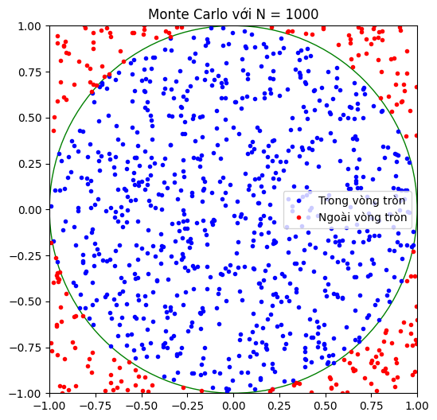

```
N = 100000, Giá trị π ước lượng: 3.14548
```

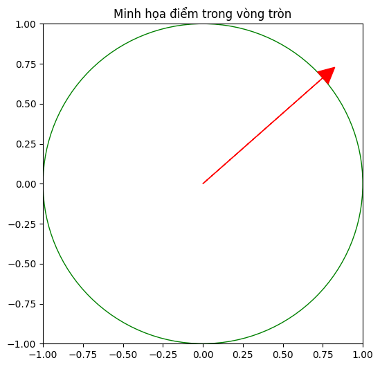

```python
import numpy as np
import matplotlib.pyplot as plt

# Định nghĩa các giá trị N để thử nghiệm
N_values = [100, 1000, 100000]

# Vòng lặp để tính toán và hiển thị kết quả cho từng N
for N in N_values:
    # Tạo các điểm ngẫu nhiên trong hình vuông [-1, 1] x [-1, 1]
    x = np.random.uniform(-1, 1, N)
    y = np.random.uniform(-1, 1, N)

    # Đếm số điểm nằm trong đường tròn đơn vị (x^2 + y^2 <= 1)
    inside_circle = x**2 + y**2 <= 1
    Nc = np.sum(inside_circle)

    # Ước lượng giá trị π
    pi_approx = 4 * Nc / N
    print(f"N = {N}, Giá trị π ước lượng: {pi_approx}")

    # Vẽ biểu đồ minh họa cho N = 1000
    if N == 1000:
        fig, ax = plt.subplots(figsize=(6, 6))
        circle = plt.Circle((0, 0), 1, color='g', fill=False)
        ax.add_patch(circle)
        ax.plot(x[inside_circle], y[inside_circle], 'b.', label='Trong vòng tròn')
        ax.plot(x[~inside_circle], y[~inside_circle], 'r.', label='Ngoài vòng tròn')
        ax.set_xlim(-1, 1)
        ax.set_ylim(-1, 1)
        ax.set_aspect('equal')
        ax.legend()
        plt.title(f'Monte Carlo với N = {N}')
        plt.savefig(f'pi_N{N}.png')
        plt.show()

# Vẽ minh họa đường mũi tên
x_arrow = 0.75
y_arrow = np.sqrt(1 - x_arrow**2)
fig, ax = plt.subplots(figsize=(6, 6))
circle = plt.Circle((0, 0), 1, color='g', fill=False)
ax.add_patch(circle)
ax.arrow(0, 0, x_arrow, y_arrow, head_width=0.1, head_length=0.1, fc='r', ec='r')
ax.set_xlim(-1, 1)
ax.set_ylim(-1, 1)
ax.set_aspect('equal')
plt.title('Minh họa điểm trong vòng tròn')
plt.savefig('pi_arrow.png')
plt.show()
```

```python
import numpy as np

def calc_pi_monte_carlo(n=100):
    pi = 0

    # Sinh ngẫu nhiên n điểm trong hình vuông [0, 1] x [0, 1]
    x = np.random.rand(n)
    y = np.random.rand(n)

    # Đếm số điểm nằm trong phần tư đường tròn đơn vị (x^2 + y^2 <= 1)
    inside_circle = x**2 + y**2 <= 1
    num_inside = np.sum(inside_circle)

    # Ước lượng π: vì đây là phần tư vòng tròn, nhân 4 để được π đầy đủ
    pi = 4 * num_inside / n

    return pi

# Kiểm tra hàm
print(calc_pi_monte_carlo())  # Kết quả với n=100
print(calc_pi_monte_carlo(1000))  # Kết quả với n=1000
```

```
3.16
3.192
```

```python
import math

print("epsilon(n=100): ", calc_pi_monte_carlo(n = 100) - math.pi)
print("epsilon(n=100): ", calc_pi_monte_carlo(n = 100) - math.pi)
print("epsilon(n=10000): ", calc_pi_monte_carlo(n = 10000) - math.pi)
print("epsilon(n=10000): ", calc_pi_monte_carlo(n = 10000) - math.pi)
print("epsilon(n=1000000): ", calc_pi_monte_carlo(n = 1000000) - math.pi)
print("epsilon(n=1000000): ", calc_pi_monte_carlo(n = 1000000) - math.pi)
```

```
epsilon(n=100):  -0.02159265358979301
epsilon(n=100):  0.1384073464102067
epsilon(n=10000):  0.01800734641020707
epsilon(n=10000):  0.0016073464102071
epsilon(n=1000000):  0.000947346410206773
epsilon(n=1000000):  -0.00014065358979298281
```